# STAT 240: Chapter 1 ggplot2

### $\cdot$ Scales:

> Editing graphical properties of the axes is done with the family of `scale_x_*` and `scale_y_*` commands.
- The asterisk specifies the type of variable on that axis. For example, `continuous` for variables like `duration` (which can take on any numeric value in a given range), or `discrete` for variables like `century` (which only take on one of a finite set of categories).
- We will most commonly use:
  - `scale_x_continuous()`
  - `scale_y_continuous()`
  - `scale_x_discrete()`
  - `scale_y_discrete()`
- Just like `geom`s, there are too many examples of `scale` functions to go over in one lecture; we will see many over the course of the class.
- Helpful arguments you can pass into `scale` functions include:
  - `breaks`, a vector of locations to draw grid lines and labels at.
  - `labels`, a vector of names to use as the label of each break-point.
  - `limits`, a vector of two numbers specifying the left and right limit of how wide/tall you want the plot to be
  - `trans`, standing for “transformation”, which allows you to do some numeric transformation of the axis; including “reverse”, “sqrt”, and “log”.

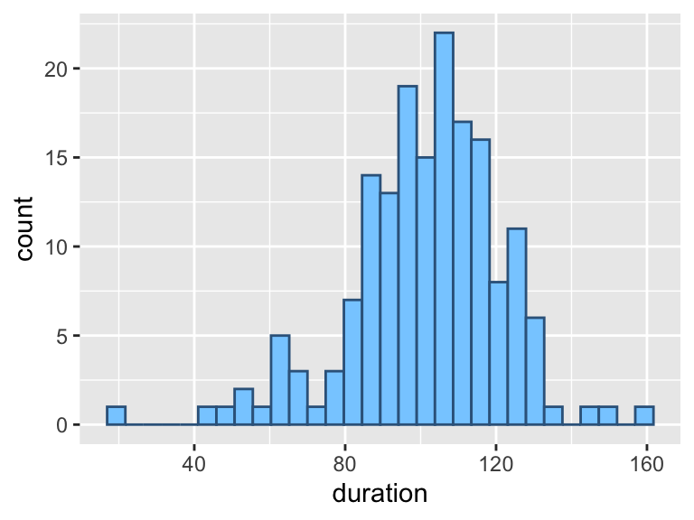

```r
# Notice ggplot's default x-axis choices
ggplot(mendota, aes(duration)) +
  geom_histogram(
    color = "steelblue4",
    fill = "skyblue1"
  )
```

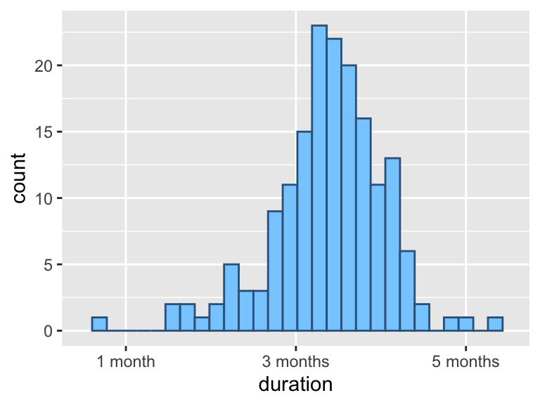

```r
ggplot(mendota, aes(duration)) +
  geom_histogram(
    color = "steelblue4",
    fill = "skyblue1"
  ) +
  scale_x_continuous(
    breaks = c(30, 90, 150),
    labels = c("1 month", "3 months", "5 months"),
    limits = c(15, 165),
    minor_breaks = NULL, # This specifies not to draw any vertical axis lines between the labeled points; not necessarily something you have to memorize, just an example of how far you can customize!
  )
```

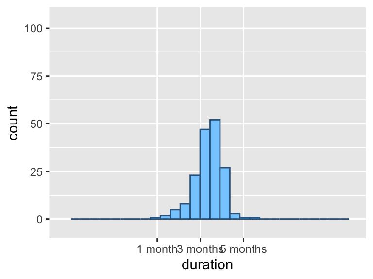

```r
ggplot(mendota, aes(duration)) +
  geom_histogram(
    color = "steelblue4",
    fill = "skyblue1"
  ) +
  scale_x_continuous(
    breaks = c(30, 90, 150),
    labels = c("1 month", "3 months", "5 months"),
    limits = c(-100, 300),
    minor_breaks = NULL
  ) +
  # Can you figure out what this addition is doing to the y-axis?
  scale_y_continuous(
    expand = expansion(mult = c(0,0.1)),
    limits = c(-10, 100)
  )
```

### $\cdot$ Color Scales:

> When color is mapped to a variable aesthetic, you can use the `viridis` color scales for accessible preset options, or use the `manual` functions to set a custom color scale.

Recall the following plot from a previous exercise:

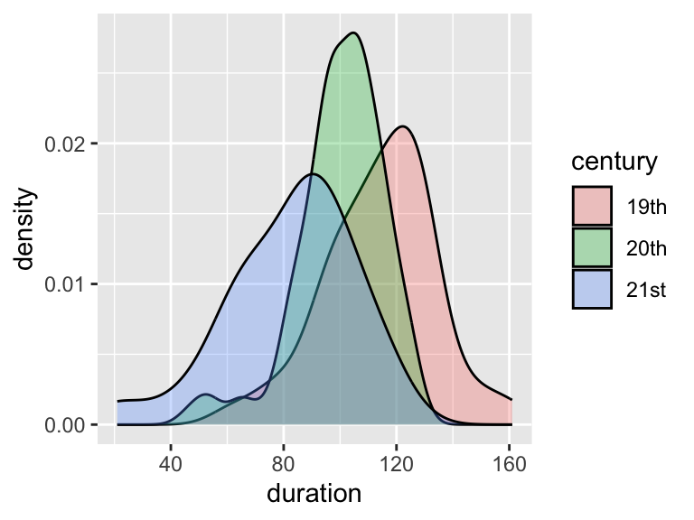

```r
ggplot(mendota, aes(x= duration, fill = century)) +
  geom_density(alpha = 0.3)
```

`ggplot`’s default color schemes can be hard to distinguish for people with common forms of color blindness. The “viridis” color scales are designed to remedy this. Depending on whether your variable is continuous (`c`) or discrete (`d`), and whether you used `color` or `fill` as the aesthetic, you can use one of the following four commands: - `scale_color_viridis_c()` - `scale_color_viridis_d()` - `scale_fill_viridis_c()` - `scale_fill_viridis_d()`

For example, in the plot above, we use `fill` as the aesthetic controlling color, with `century` a discrete/categorical variable, so we use `scale_fill_viridis_d()`.

Examples:

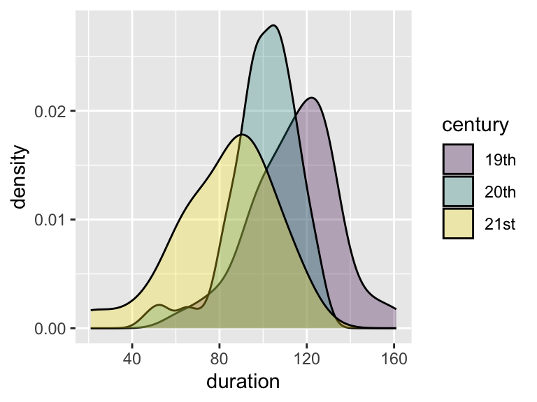

```r
ggplot(mendota, aes(x= duration, fill = century)) +
  geom_density(alpha = 0.3) +
  scale_fill_viridis_d()
```

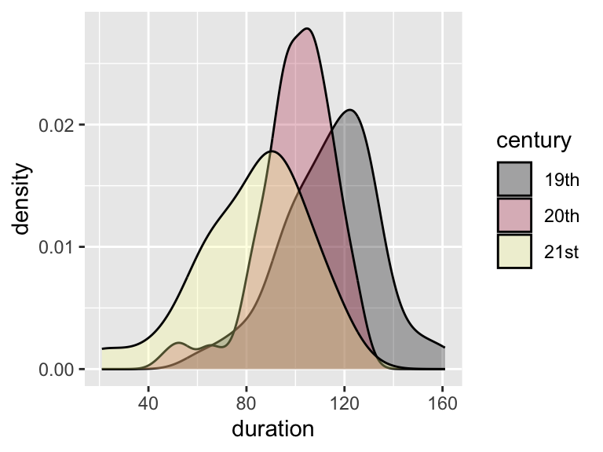

```r
ggplot(mendota, aes(x= duration, fill = century)) +
  geom_density(alpha = 0.3) +
  scale_fill_viridis_d(option = "inferno")
```

Alternatively, you might have a custom color scheme in mind. `scale_color_manual` and `scale_fill_manual` exist to help you; the `values` argument accept a vector of pairs, where you map values of the categorical variable to colors.

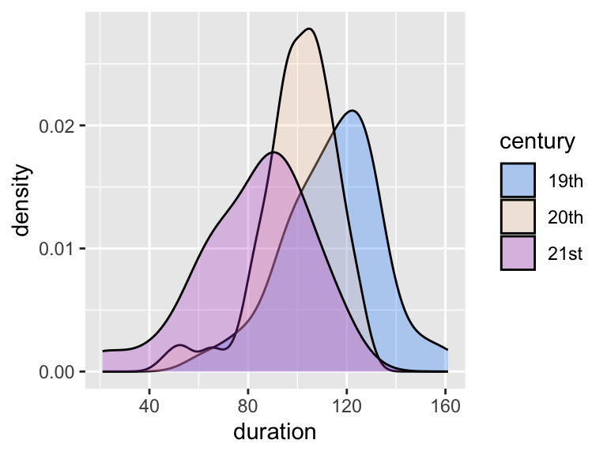

```r
ggplot(mendota, aes(x= duration, fill = century)) +
  geom_density(alpha = 0.3) +
  scale_fill_manual(
    values = c("19th" = "dodgerblue", "20th" = "peachpuff", "21st" = "mediumorchid")
    )
```

There are many options within viridis, see [here (scroll a little down)](https://cran.r-project.org/web/packages/viridis/vignettes/intro-to-viridis.html) for more details.

### $\cdot$ Plot Labels:

> All plot labeling can be done with the `labs()` (standing for labels) function.

`labs()` can be used to add a title, subtitle, and caption; see placement examples below. It can also be used to adjust the axes labels and legend titles. The legend title can be changed through `labs()` by using the name of whatever aesthetic you used to create the legend.

For example, in this plot we create the legend with `fill = century`, so the legend title is adjusted with `fill = "intended legend title"`.

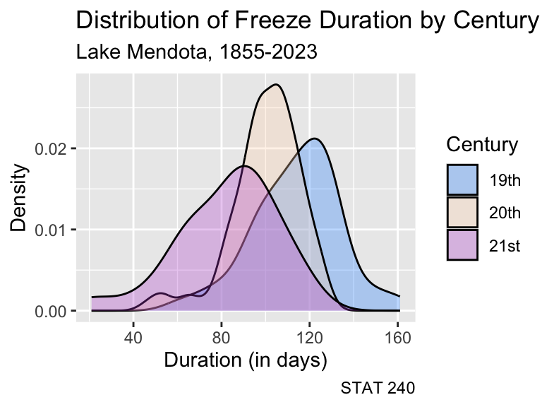

```r
densityPlot = ggplot(mendota, aes(x= duration, fill = century)) +
  labs(
    title = "Distribution of Freeze Duration by Century",
    subtitle = "Lake Mendota, 1855-2023",
    caption = "STAT 240",

    x = "Duration (in days)",
    y = "Density",
    fill = "Century" # If you created your legend with the size aesthetic, this would be size = "legend title", or color would be color = "legend title", et cetera
  ) +
  geom_density(alpha = 0.3) +
  scale_fill_manual(
    values = c("19th" = "dodgerblue", "20th" = "peachpuff", "21st" = "mediumorchid")
    )

densityPlot
```

### $\cdot$ Themes:

> `ggplot2` comes with many built-in themes to improve the appearance of the graph over the default theme, such as `theme_minimal()`.

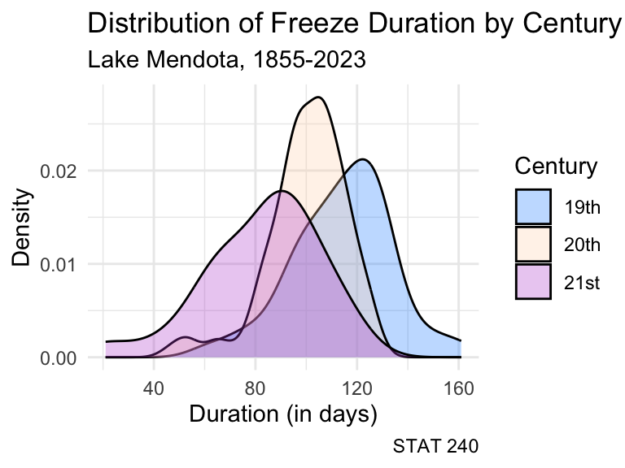

```r
densityPlot +
  theme_minimal()
```

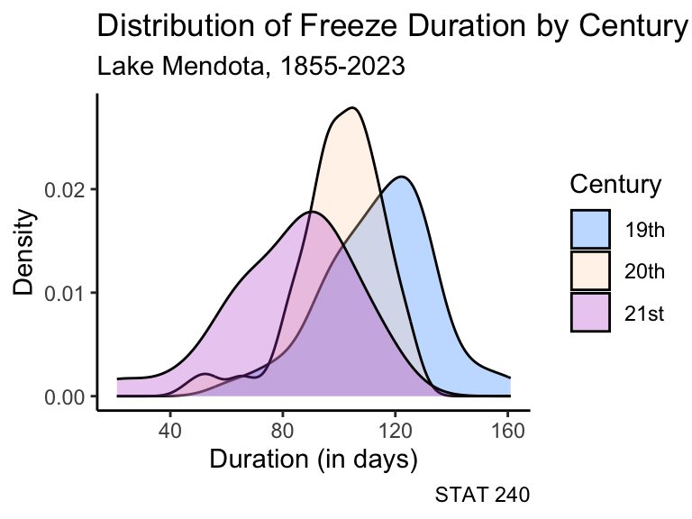

```r
densityPlot +
  theme_classic()
```

This [link](https://ggplot2.tidyverse.org/reference/ggtheme.html) contains a complete list of themes.

### $\cdot$ Shortcut Functions:

The “general” form of all the customization functions are discussed above. Many of the more common tasks have shortcut functions; they are useful if you only need to make one change. *Note:* The general form because they can accomplish everything these shortcuts can do and more, and you have less functions to memorize.

Examples of shortcut functions include:

- `xlim(c(a, b))` is the same as `scale_x_continuous(limits = c(a, b))`, and similarly for `y`.
- `scale_x_reverse()` is the same as `scale_x_continuous(trans = "reverse")`, and similarly for `y`.
- `ggtitle("my title")` is the same as `labs(title = "my title")`.
- `xlab("x axis title")` is the same as `labs(x = "x axis title")`, and similarly `ylab()` can be used for `y`.

##### Another EXERCISE: This uses all the topics we have covered in the lecture note.

> Interpreting a Faceted Plot: Consider the graph below and choose from the given options to correctly interpret the plot:

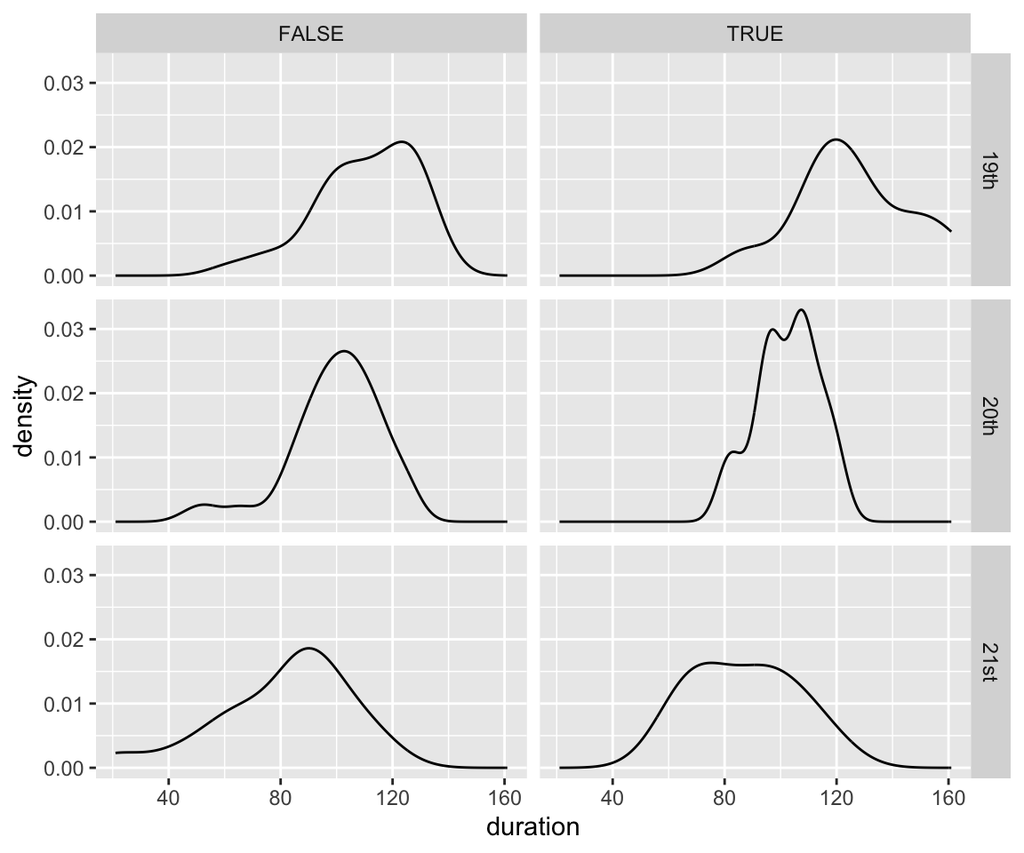

```r
ggplot(mendota, aes(x = duration)) +
  geom_density() +
  facet_grid(rows = vars(century), cols = vars(leap_year))
```

- The top left panel shows the distribution of `duration` among **(leap years/non-leap years)** in the **(19th/20th/21st)** century.
- The bottom right panel shows the distribution of `duration` among **(leap years/non-leap years)** in the **(19th/20th/21st)** century.
- We don’t expect there to be a difference in average duration between non-leap years and leap years. This is illustrated by the fact that each **(row of panels/column of panels)** has roughly the same center across each of its panels.
- We do expect there to be a difference in average duration across centuries. This is illustrated by the fact that each **(row of panels/column of panels)** has different centers across each of its panels.

> Technical takeaway: The subgroup represented in an individual faceted panel can be defined by one OR two variables; the faceting commands do a decent but not perfect job of labeling them.

> Philosophical takeaway: Faceting is another valuable tool for showing two-variable relationships. It is especially helpful when we have too many subgroups to overlay on a single panel.
- Philosophical takeaway continued: Notice how difficult it is to encode `leap_year` AND `century` with just aesthetics.

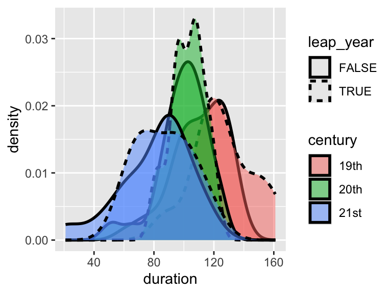

```r
ggplot(mendota, aes(x = duration, fill = century, linetype = leap_year)) +
  geom_density(alpha = 0.5, size = 1)
```

> In the `mpg` dataset use the variables `cty`, `hwy` `displ`, `drv` and `year` to recreate the graph below. Use all the concepts we have learned so far.

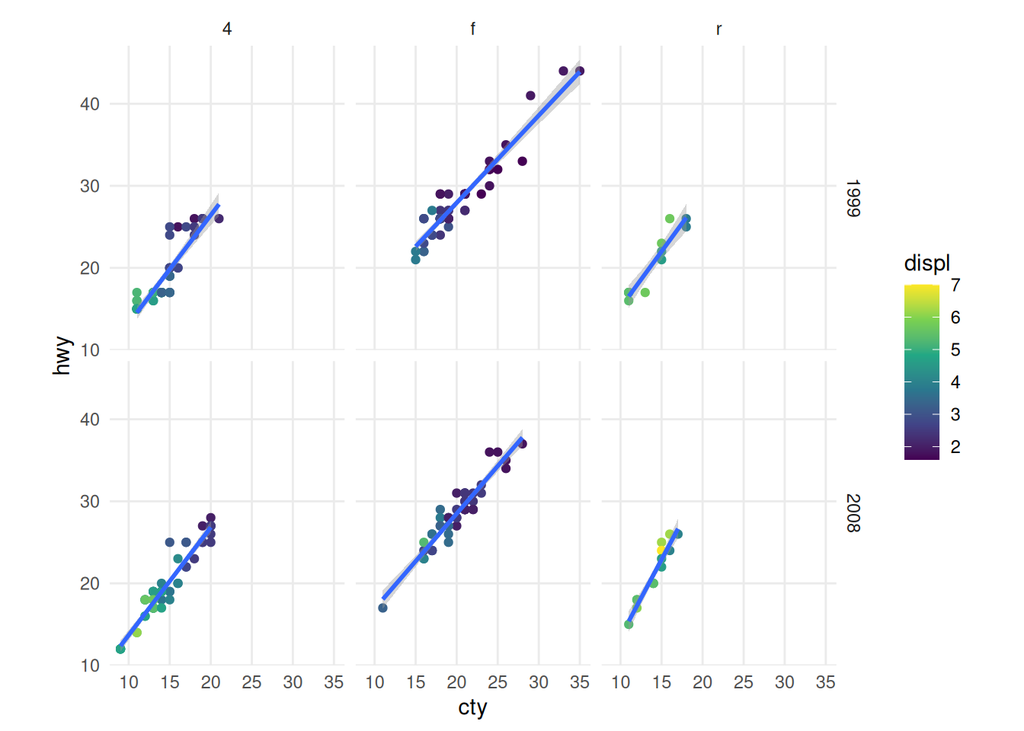

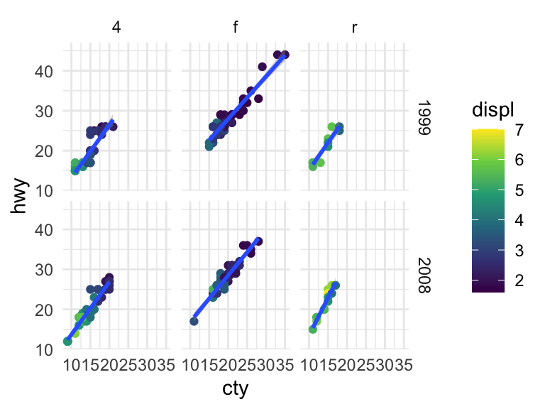

```r
ggplot(mpg, aes(cty, hwy, col = displ)) +
  geom_point() +
  geom_smooth(method = "lm") +
  facet_grid(rows = vars(year), cols = vars(drv)) +
  theme_minimal() +
  scale_color_viridis_c()
```